# Integrative single-cell analysis

shiquan@genomicn.cn

2019-11-11

## 1. 背景介绍

在生物学实验设计中，常见的一种研究思路是通过比较两组或者多组实验数据，发现或验证与生物学差异相关的各种实验因素。比如通过比较不同物种相同组织类型的基因表达来研究进化与基因的保守性。比如通过对遗传病患者非正常发育的组织进行测序研究，以及和正常人的对应的组织细胞进行分析，明确致病基因以及调控。再比如通过对同一物种的同一组织类型，在不同发育时期的转录组数据进行对比，发现不同发育阶段的标记基因，研究该组织在整个发育过程中基因表达调控网络。以上实验设计中，最理想的情况下是稳定所有不相关的因素，不同实验之间有且仅有一个与研究相关的实验条件的改变，在这种假设成立的情况下我们可以推断，任何表型上的差异都是由该实验条件的改变而引起的。

然而在实际的单细胞转录组测序（Single-cell transcriptome sequencing）实验过程中，样品本身差异、⽂库构建差异、实验条件、实验人员等一系列因素都能影响单细胞实验中转录本检测数量的改变。这种差异我们称之为批次效应（Batch effect）。由于批次效应的存在，不同实验之间单个细胞整体的检测转录本数量存在较⼤差异，甚⾄掩盖真实的生物学差异。即使在同一个实验过程中，由于不同细胞间转录本捕获效率存在差异，细胞间亦无法直接比较基因表达差异。因此对数据的进行标准化处理是单细胞转录组测序中最重要的步骤之一。

本实验包含两个部分，第一部分通过对不同实验平台产生的两组人类 PBMC 数据进行整合分析，使学员明确样品批次矫正的意义和方法。第二部分是批次矫正方法的延伸，我们将通过整合同一细胞类型两种组学数据，进一步应用样品标准化。

## 2. 数据准备

打开 R 操作界面，加载相关函数包。

```r
require(Seurat) # 单细胞组学数据分析包
require(ggplot2)    # 画图包
require(data.table) # 快速读取本地文件的工具包
```

## 3. 同一样品类型，不同实验数据整合

数据说明: 本节测试所使用数据为同一志愿者外周血样品在两个不同的单细胞转录组建库测序平台的测序结果。

### 3.1 测试 1：不同平台的两个数据集直接根据基因进行合并，查看两个不同平台的数据在聚类图中的分布

读取原始数据， 该文件为10X Genomics 公司cellranger 软件生成的基因表达矩阵文件。文件格式为hdf5，该格式是一种通用的用于存储和分发科学数据的一种数据格式。 该格式有成为单细胞数据分析领域标准数据存储格式的趋势。 官网 https://support.hdfgroup.org/HDF5/

```r
pbmc2.data <- Read10X_h5("./sample_2_feature_bc_matrix.h5")
```

相同样品在华大单细胞转录组建库平台的测试结果，利用`data.table` 包提供的`fread` 函数快速读取文件，并保存为data.frame 对象

```r
pbmc3.data <- as.data.frame(fread("./sample_3_matrix.tsv",header=T))
# 该文件第一列为基因名，将其转换为表格的列名后，删除第一列
rownames(pbmc3.data) = pbmc3.data$ID
pbmc3.data = pbmc3.data[,-1]
```

提取两个表格里的共同表达基因， 即交集。 一般情况下合并两个表达矩阵时尽量取基因的并集。此处为了操作方便取交集。

```r
intersect.genes = intersect(rownames(pbmc2.data),rownames(pbmc3.data))
# 将两个实验的表达矩阵直接根据基因进行合并
pbmc.native = cbind(pbmc2.data[intersect.genes ,],pbmc3.data[intersect.genes ,])
# 查看合并后细胞和基因个数
dim(pbmc.native)
```

```
## [1] 19431  6610
```

保留两个实验的原始细胞ID，方便后面区分。实际操作过程中可以将细胞名重命名为 “样品名”_“细胞名”，Seurat会自动提取符号“_”前面的字符序列为样品名。

```r
bcs.exper1 = colnames(pbmc2.data)
bcs.exper2 = colnames(pbmc3.data)
```

Seurat scRNA 分析流程

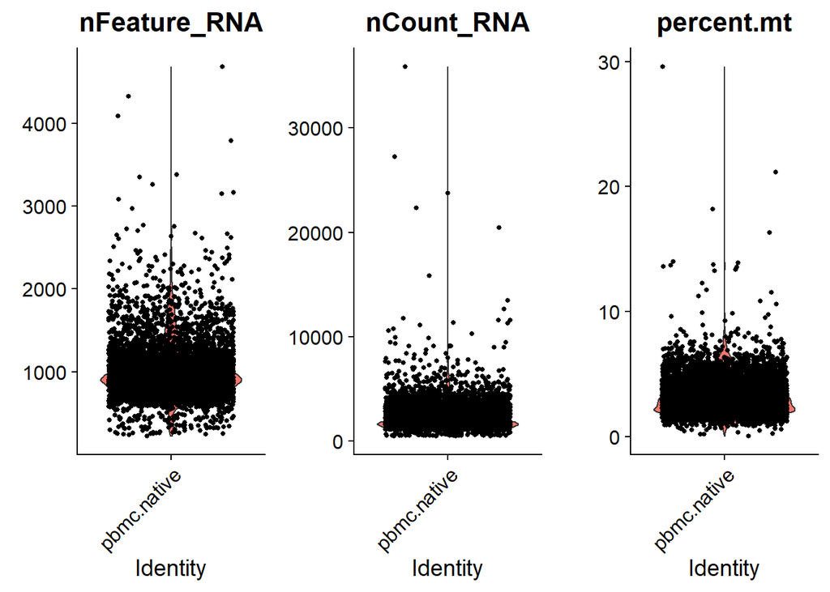

```r
pbmc.native.obj <- CreateSeuratObject(counts = pbmc.native , project = "pbmc.native", min.cells = 3, min.features = 200)
pbmc.native.obj[["percent.mt"]] <- PercentageFeatureSet(pbmc.native.obj , pattern = "^MT-")
VlnPlot(pbmc.native.obj , features = c("nFeature_RNA", "nCount_RNA", "percent.mt"), ncol = 3)
```

```r
pbmc.native.obj <- subset(pbmc.native.obj , subset = percent.mt < 10)
pbmc.native.obj <- NormalizeData(pbmc.native.obj , normalization.method = "LogNormalize", scale.factor = 10000)
pbmc.native.obj <- FindVariableFeatures(pbmc.native.obj , selection.method = "vst", nfeatures = 2000)
all.genes <- rownames(pbmc.native.obj)
pbmc.native.obj <- ScaleData(pbmc.native.obj , features = all.genes)
pbmc.native.obj <- RunPCA(pbmc.native.obj , features = VariableFeatures(object = pbmc.native.obj))
```

```
## PC_ 1
## Positive:  AC138811.2, RPS10-NUDT3, AC135178.2, EEF1G, AP002990.1, JUN, TRBC1, SYNE2, AL928654.3, PPIA
##     SENP3-EIF4A1, NKG7, AC004922.1, TNFAIP3, TSIX, KLRC4-KLRK1, KLRK1, AC010619.1, NME1-NME2, FOSB
##     DUSP2, CST7, IL2RB, NME2, TBC1D4, GZMA, LTB, XIST, HIST1H4C, CTSW
## Negative:  FCN1, LYZ, MNDA, CST3, S100A12, VCAN, S100A8, CSTA, SERPINA1, S100A9
##     IFI30, CD14, CLEC12A, LST1, MS4A6A, SPI1, LGALS2, CFD, TMEM176B, TYMP
##     CLEC7A, CYBB, CD68, FGL2, CD36, CSF3R, GRN, AIF1, CTSS, MGST1
## PC_ 2
## Positive:  CD79A, MS4A1, IGHM, LINC00926, CD79B, IGHD, BANK1, LTB, TCL1A, RPL34
##     RPS6, HLA-DRA, RPS18, RPS2, CD22, EEF1A1, HLA-DQB1, MEF2C, RPL41, RPL39
##     RPL10, FCER2, VPREB3, FCRL1, RPL8, IGKC, HLA-DMB, FAM129C, HVCN1, IGLC3
## Negative:  NKG7, CST7, GZMA, GNLY, FGFBP2, GZMB, CCL5, PRF1, GZMH, S100A4
##     SRGN, KLRD1, FCGR3A, ID2, IL2RB, CCL4, CTSW, SPON2, MYOM2, S1PR5
##     ADGRG1, TYROBP, PLEK, SYNE2, KLRC4-KLRK1, TRDC, KLRK1, HOPX, KLRF1, CD300A
## PC_ 3
## Positive:  HLA-DRB5, HLA-DRB1, MS4A1, HLA-DQA1, HLA-DQA2, CD79A, CD74, IGHM, HLA-DPB1, CD79B
##     LINC00926, BANK1, HLA-DPA1, HLA-DRA, AL645941.2, IGHD, CD22, HLA-DMB, MEF2C, IRF8
##     SWAP70, HLA-DQB1, AL928654.3, HLA-DMA, SPIB, FCRL1, RALGPS2, KLF6, FAM129C, JUN
## Negative:  RPL34, EEF1A1, RPL10, RPL41, RPS18, RPL3, RPL39, RPS6, RPL17, RPL36
##     MALAT1, RPS2, RPLP1, SERF2, RPL8, VIM, AC114760.2, CAMK4, SNHG25, S100A9
##     CD27, HBB, PGK1, CD8B, CELF2, H3F3A, PPA1, AC016831.5, S100A8, S100B
## PC_ 4
## Positive:  TUBB1, CAVIN2, PF4, GP9, GNG11, ACRBP, RGS18, NRGN, PPBP, HIST1H2AC
##     ITGA2B, CLU, PTCRA, CMTM5, F13A1, TREML1, TMEM40, ESAM, SPARC, MPIG6B
##     MMD, MPP1, DMTN, PRKAR2B, TSC22D1, AC147651.1, MAP3K7CL, GMPR, C2orf88, HIST1H2BJ
## Negative:  RPLP1, RPL34, RPL10, S100A4, RPS2, S100A6, EEF1A1, CYBA, NKG7, RPS18
##     RPS6, CST7, FOS, TYROBP, PPIA, LGALS1, FCGR3A, RPL41, GNLY, KLF6
##     FGFBP2, JUN, ID2, CRIP1, PRF1, RPL3, GZMA, GZMB, KLRD1, GZMH
## PC_ 5
## Positive:  MALAT1, RPL17, SERF2, CCL5, KLRB1, ACTB, H3F3A, KLRD1, GZMA, GZMB
##     HBB, CST7, GZMH, CMC1, PRF1, NKG7, RPL41, CTSW, CYBA, PGK1
##     C12orf75, RPL39, FGFBP2, RPL36, CELF2, AC114760.2, HOPX, CCL4, RPL3, HLA-DPB1
## Negative:  AP002990.1, AC138811.2, RPS10-NUDT3, EEF1G, AC135178.2, FOS, FOSB, JUN, AC010619.1, TSIX
##     TBC1D4, NME1-NME2, SENP3-EIF4A1, AL928654.3, AC004922.1, NME2, XIST, TNFAIP3, PPIA, GIMAP1-GIMAP5
##     RGCC, LRRN3, BOD1L1, AIF1, HSPE1-MOB4, AL121594.1, JAML, KLF6, SOCS3, TTN
```

```r
pbmc.native.obj <- FindNeighbors(pbmc.native.obj , dims = 1:10)
pbmc.native.obj <- FindClusters(pbmc.native.obj , resolution = 0.5)
```

```
## Modularity Optimizer version 1.3.0 by Ludo Waltman and Nees Jan van Eck
##
## Number of nodes: 6581
## Number of edges: 224987
##
## Running Louvain algorithm...
## Maximum modularity in 10 random starts: 0.9151
## Number of communities: 13
## Elapsed time: 1 seconds
```

```r
pbmc.native.obj <- RunUMAP(pbmc.native.obj , dims = 1:10)
```

提取细胞聚类后的各种参数信息到一个表格中，方便后面根据需求自定义画图。注意：`pbmc.native.obj@reductions$umap@cell.embeddings` 这个矩阵为细胞表达数据降维为2维平面后的坐标

```r
coor = cbind(pbmc.native.obj@meta.data , pbmc.native.obj@reductions$umap@cell.embeddings)
# 查看合并数据是否成功
head(coor)
```

```
##                     orig.ident nCount_RNA nFeature_RNA percent.mt
## AAACCTGAGGATGGTC-1 pbmc.native       2516          911   2.265501
## AAACCTGAGTGTACCT-1 pbmc.native       3034         1081   2.735662
## AAACCTGAGTTGAGAT-1 pbmc.native       2997         1080   2.135469
## AAACCTGCAAACCTAC-1 pbmc.native       3627         1142   1.295837
## AAACCTGCAATCCAAC-1 pbmc.native       3220         1008   1.832298
## AAACCTGCAGCTATTG-1 pbmc.native       4253         1419   1.622384
##                    RNA_snn_res.0.5 seurat_clusters      UMAP_1     UMAP_2
## AAACCTGAGGATGGTC-1               3               3   4.7491765  -8.878544
## AAACCTGAGTGTACCT-1               8               8   2.4468877 -10.642282
## AAACCTGAGTTGAGAT-1               9               9 -13.4232082   4.296649
## AAACCTGCAAACCTAC-1               8               8   1.9480612  -9.871566
## AAACCTGCAATCCAAC-1               2               2   0.1619171 -13.003177
## AAACCTGCAGCTATTG-1               8               8   2.8916434  -8.825853
```

```r
# 添加新的列 sample，用于区分两个实验
coor$sample = "sample 1"
coor[bcs.exper2 ,]$sample="sample 2"
head(coor)
```

```
##                     orig.ident nCount_RNA nFeature_RNA percent.mt
## AAACCTGAGGATGGTC-1 pbmc.native       2516          911   2.265501
## AAACCTGAGTGTACCT-1 pbmc.native       3034         1081   2.735662
## AAACCTGAGTTGAGAT-1 pbmc.native       2997         1080   2.135469
## AAACCTGCAAACCTAC-1 pbmc.native       3627         1142   1.295837
## AAACCTGCAATCCAAC-1 pbmc.native       3220         1008   1.832298
## AAACCTGCAGCTATTG-1 pbmc.native       4253         1419   1.622384
##                    RNA_snn_res.0.5 seurat_clusters      UMAP_1     UMAP_2
## AAACCTGAGGATGGTC-1               3               3   4.7491765  -8.878544
## AAACCTGAGTGTACCT-1               8               8   2.4468877 -10.642282
## AAACCTGAGTTGAGAT-1               9               9 -13.4232082   4.296649
## AAACCTGCAAACCTAC-1               8               8   1.9480612  -9.871566
## AAACCTGCAATCCAAC-1               2               2   0.1619171 -13.003177
## AAACCTGCAGCTATTG-1               8               8   2.8916434  -8.825853
##                      sample
## AAACCTGAGGATGGTC-1 sample 1
## AAACCTGAGTGTACCT-1 sample 1
## AAACCTGAGTTGAGAT-1 sample 1
## AAACCTGCAAACCTAC-1 sample 1
## AAACCTGCAATCCAAC-1 sample 1
## AAACCTGCAGCTATTG-1 sample 1
```

查看聚类结果

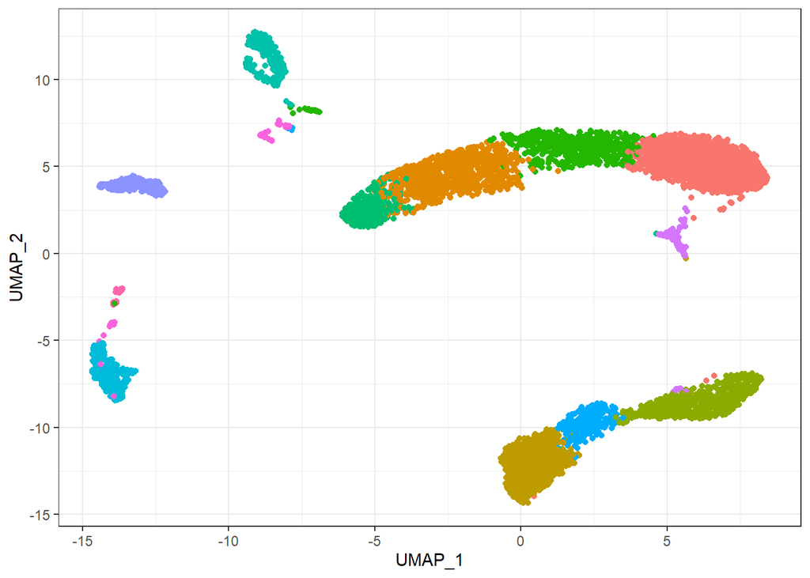

```r
ggplot(coor) + geom_point(aes(x=UMAP_1,y=UMAP_2,color=coor$seurat_clusters)) + theme_bw() + theme(legend.position = "none")
```

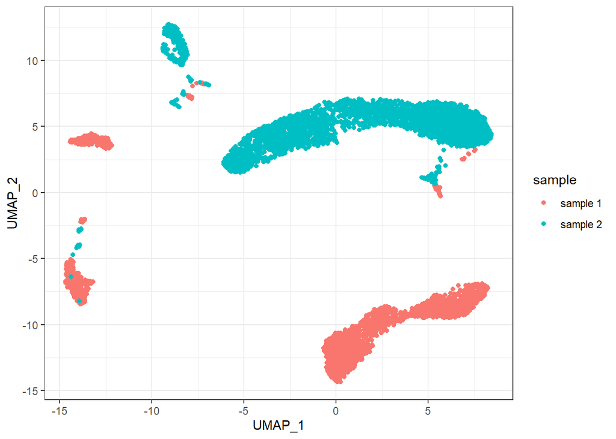

```r
# 查看不同实验产生的细胞在聚类图中的分布
ggplot(coor) + geom_point(aes(x=UMAP_1,y=UMAP_2,color=sample)) + theme_bw()
```

通过以上的实验我们可以看到两个实验产生的细胞聚类不能很好的聚在一起，显然与两个实验来自于同样一个捐献者的相同类型样品这一前提假设不一致。请各位思考，造成这种不一致的原因有哪些？

### 3.2 利用“典型相关分析算法”去除批次效应后重新对数据进行解读

典型相关分析（Canonical correction analysis, CCA）算法是 Seurat 分析包默认的一种进行批次矫正，数据整合分析的算法。

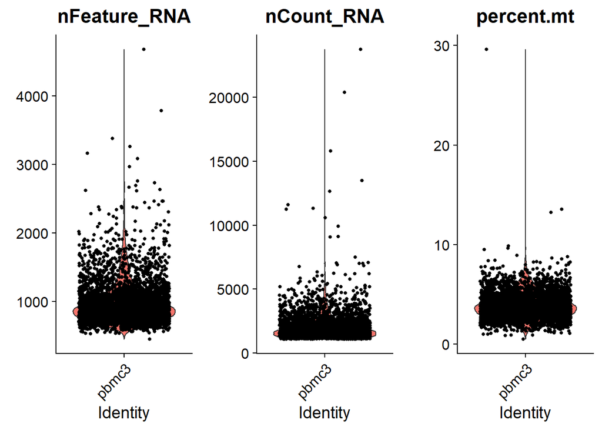

```r
# 构建实验1 的Seurat 对象， 标准化后寻找top1000 的差异表达基因。
pbmc2 <- CreateSeuratObject( counts = pbmc2.data , project = "pbmc2", min.cells = 3, min.features = 200)
pbmc2 [["percent.mt"]] <- PercentageFeatureSet( pbmc2 , pattern = "^MT-")
pbmc2 <- subset( pbmc2 , subset = percent.mt < 10)
pbmc2 <- NormalizeData( pbmc2 , normalization.method = "LogNormalize", scale.factor = 10000)
pbmc2 <- FindVariableFeatures( pbmc2 , selection.method = "vst", nfeatures = 1000)

# 构建实验2 的Seurat 对象， 标准化后寻找top1000 的差异表达基因。
pbmc3 <- CreateSeuratObject( counts = pbmc3.data , project = "pbmc3", min.cells = 3, min.features = 200)
pbmc3 [["percent.mt"]] <- PercentageFeatureSet( pbmc3 , pattern = "^MT-")
VlnPlot( pbmc3 , features = c("nFeature_RNA", "nCount_RNA", "percent.mt"), ncol = 3)
```

```r
pbmc3 <- subset( pbmc3 , subset = percent.mt < 5)
pbmc3 <- NormalizeData( pbmc3 , normalization.method = "LogNormalize", scale.factor = 10000)
pbmc3 <- FindVariableFeatures( pbmc3 , selection.method = "vst", nfeatures = 1000)

# 给来自两个实验的细胞标记标签
pbmc2$batch= "sample 1"
pbmc3$batch= "sample 2"
# 组成一个列表
pbmc.list = list(pbmc2 ,pbmc3)
```

**请参考CCA 矫正的步骤：** 1. Data preprocessing and gene selection.  
2. Define a shared correlation space with canonical correlation analysis.  
3. Identify rare non-overlapping subpopulations.  
4. Align correlated subspaces using dynamic time warping.  
5. Integrated analysis across data sets (clustering, trajectory building, differential expression).  
参考: Butler et al., 2018 , Nature Biotechnology

```r
# 利用CCA 算法寻找不同实验细胞的 "anchors"
anchors <- FindIntegrationAnchors(object.list = pbmc.list , dims = 1:20)
```

```
## Computing 2000 integration features
```

```
## Scaling features for provided objects
```

```
## Finding all pairwise anchors
```

```
## Running CCA
```

```
## Merging objects
```

```
## Finding neighborhoods
```

```
## Finding anchors
```

```
##  Found 7754 anchors
```

```
## Filtering anchors
```

```
##  Retained 3249 anchors
```

```
## Extracting within-dataset neighbors
```

```r
# 整合数据
combined <- IntegrateData(anchorset = anchors , dims = 1:20)
```

```
## Merging dataset 1 into 2
```

```
## Extracting anchors for merged samples
```

```
## Finding integration vectors
```

```
## Finding integration vector weights
```

```
## Integrating data
```

```r
# Seurat 矫正， 聚类流程
combined <- ScaleData(combined , verbose = FALSE)
combined <- RunPCA(combined , npcs = 30, verbose = FALSE)
combined <- RunUMAP(combined , reduction = "pca", dims = 1:20)
combined <- FindNeighbors(combined , reduction = "pca", dims = 1:20)
combined <- FindClusters(combined , resolution = 0.5)
```

```
## Modularity Optimizer version 1.3.0 by Ludo Waltman and Nees Jan van Eck
##
## Number of nodes: 5930
## Number of edges: 264233
##
## Running Louvain algorithm...
## Maximum modularity in 10 random starts: 0.8874
## Number of communities: 12
## Elapsed time: 0 seconds
```

```r
coor1 = cbind(combined@meta.data , combined@reductions$umap@cell.embeddings)
head(coor1)
```

```
##                    orig.ident nCount_RNA nFeature_RNA percent.mt    batch
## AAACCTGAGGATGGTC-1      pbmc2       2519          913   2.262803 sample 1
## AAACCTGAGTGTACCT-1      pbmc2       3042         1086   2.728468 sample 1
## AAACCTGAGTTGAGAT-1      pbmc2       3000         1083   2.133333 sample 1
## AAACCTGCAAACCTAC-1      pbmc2       3636         1147   1.292629 sample 1
## AAACCTGCAATCCAAC-1      pbmc2       3230         1012   1.826625 sample 1
## AAACCTGCAGCTATTG-1      pbmc2       4257         1420   1.620860 sample 1
##                    integrated_snn_res.0.5 seurat_clusters     UMAP_1
## AAACCTGAGGATGGTC-1                      3               3 -3.6682893
## AAACCTGAGTGTACCT-1                      2               2 -0.8384547
## AAACCTGAGTTGAGAT-1                      6               6 13.3328878
## AAACCTGCAAACCTAC-1                      2               2  0.2928197
## AAACCTGCAATCCAAC-1                      0               0 -0.9156069
## AAACCTGCAGCTATTG-1                      2               2 -0.1519487
##                        UMAP_2
## AAACCTGAGGATGGTC-1  8.4675195
## AAACCTGAGTGTACCT-1 -1.9003131
## AAACCTGAGTTGAGAT-1 -4.6551120
## AAACCTGCAAACCTAC-1  0.2202316
## AAACCTGCAATCCAAC-1 -4.8770685
## AAACCTGCAGCTATTG-1  1.7710416
```

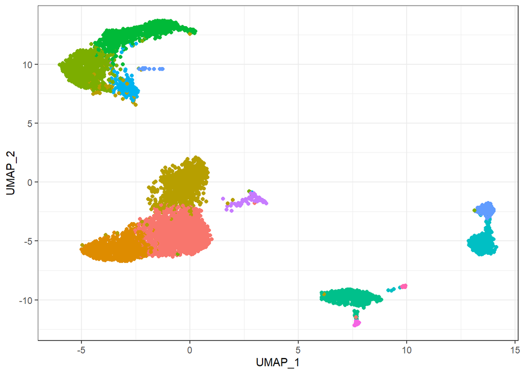

```r
# 聚类结果
ggplot(coor1) + geom_point(aes(x=UMAP_1,y=UMAP_2,color=seurat_clusters)) + theme_bw() + theme(legend.position = "none")
```

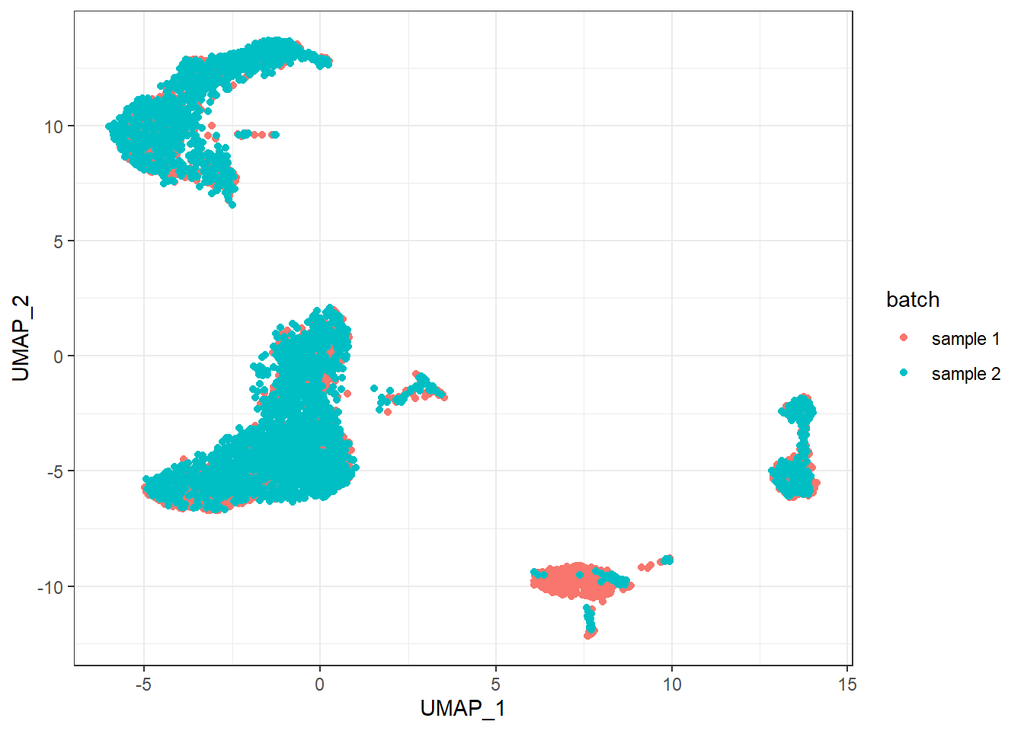

```r
# 不同实验产生的细胞在不同类型中的分布
ggplot(coor1) + geom_point(aes(x=UMAP_1,y=UMAP_2,color=batch)) + theme_bw()
```

关于本小结的分析步骤可以参考 https://satijalab.org/seurat/v3.1/immune_alignment.html

## 4. 同一样品类型，不同组学实验数据整合

染色质开放是相对应基因表达的必要条件，根据基因启动子上下游开放区域强弱（或多少）预测基因是否表达，或者表达强弱是目前常用的关联单细胞开放区域测序数据和单细胞转录组数据的常用方法。由染色质开放区域预测出的基因表达活性值（gene activity score） 被转换成基因表达矩阵，进一步利用 CCA 算法与相同类型细胞的单细胞转录组数据进行整合。本实验利用公共数据库中获得的人 PBMC scRNA 和 scATAC 数据进行整合分析。该数据在前面的课程中被使用到，这里我们直接从聚类完成后的状态开始进行整合分析。

```r
# 加载数据
load("pbmc_atac.rds")
load("pbmc_rna.rds")
```

```r
# 利用CCA 算法寻找两组数据间的 "anchors"
genes.use <- VariableFeatures(pbmc.rna)
transfer.anchors <- FindTransferAnchors(reference = pbmc.rna, query = pbmc.atac, reduction = "cca")
```

```
## Running CCA
```

```
## Merging objects
```

```
## Finding neighborhoods
```

```
## Finding anchors
```

```
##  Found 10768 anchors
```

```
## Filtering anchors
```

```
##  Retained 1332 anchors
```

```
## Extracting within-dataset neighbors
```

根据scRNA 注释信息， 预测 atac 分群细胞类型，一般情况下到这一步就可以分细胞类型进行分析了。

```r
# celltype.predictions <- TransferData(anchorset = transfer.anchors , refdata = pbmc.rna$celltype , weight.reduction = pbmc.atac [["lsi"]])
# pbmc.atac <- AddMetaData(pbmc.atac , metadata = celltype.predictions)

# imputation
refdata <- GetAssayData(pbmc.rna , assay = "RNA", slot = "data")[genes.use , ]
imputation <- TransferData(anchorset = transfer.anchors , refdata = refdata , weight.reduction = pbmc.atac[["lsi"]])
```

```
## Finding integration vectors
```

```
## Finding integration vector weights
```

```
## Transfering 2000 features onto reference data
```

```r
pbmc.atac[["RNA"]] <- imputation

# 合并两个组学数据
coembed <- merge(x = pbmc.rna , y = pbmc.atac)
# 矫正， 聚类
coembed <- ScaleData(coembed , features = genes.use , do.scale = FALSE)
```

```
## Centering data matrix
```

```r
coembed <- RunPCA(coembed , features = genes.use , verbose = FALSE)
coembed <- RunUMAP(coembed , dims = 1:30)
```

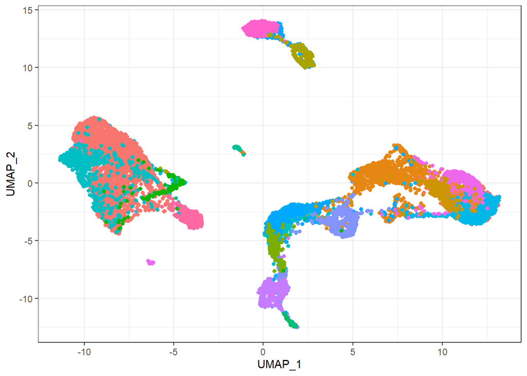

```r
coor3 = cbind(coembed@meta.data ,coembed@reductions$umap@cell.embeddings)

# 聚类结果
ggplot(coor3) + geom_point(aes(x=UMAP_1,y=UMAP_2,color=seurat_clusters)) + theme_bw() + theme(legend.position = "none")
```

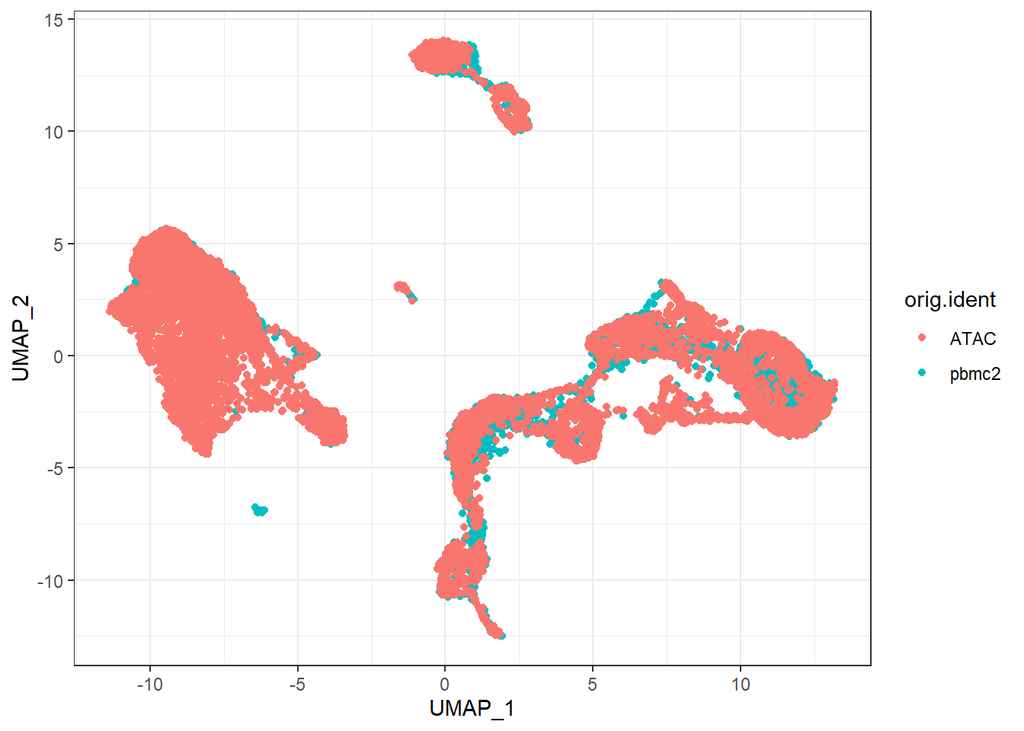

```r
# 不同实验产生的细胞在不同类型中的分布
ggplot(coor3) + geom_point(aes(x=UMAP_1,y=UMAP_2,color=orig.ident)) + theme_bw()
```

## 5. 参考资料

1. Seurat 网站：https://satijalab.org/seurat
2. Signac 网站：https://satijalab.org/signac/
3. Cicero 网站：https://cole-trapnell-lab.github.io/cicero-release/
4. https://broadinstitute.github.io/2019_scWorkshop/
5. https://github.com/seandavi/awesome-single-cell
6. 更多参考文献在本课程对应课件中。